# Week 6 / Day 2

## MVP

### Q1.

Load the data, clean_names() and explore it.

```r
phones <- read_csv("data/20190928-items.csv") %>% clean_names()
```

```r
glimpse(phones)
```

```
Rows: 792
Columns: 9
$ asin          <chr> "B0000SX2UC", "B0009N5L7K", "B000SKTZ0S", "B00198M12M", "B001AO4O…
$ brand         <chr> "Nokia", "Motorola", "Motorola", "Nokia", "Motorola", "Motorola",…
$ title         <chr> "Dual-Band / Tri-Mode Sprint PCS Phone w/ Voice Activated Dialing…
$ url           <chr> "https://www.amazon.com/Dual-Band-Tri-Mode-Activated-Dialing-Back…
$ image         <chr> "https://m.media-amazon.com/images/I/2143EBQ210L._AC_UY218_SEARCH…
$ rating        <dbl> 3.0, 2.9, 2.6, 2.4, 3.3, 3.2, 2.0, 2.7, 3.2, 3.5, 2.9, 2.9, 2.8, …
$ review_url    <chr> "https://www.amazon.com/product-reviews/B0000SX2UC", "https://www…
$ total_reviews <dbl> 14, 7, 22, 5, 21, 12, 1, 3, 8, 133, 2, 18, 201, 76, 131, 66, 3, 1…
$ prices        <chr> NA, "$49.95", NA, NA, NA, NA, "$78.99", NA, "$99.99", "$59.89", "…
```

```r
head(phones)
```

| asin | brand | title | url | image | rating | review_url | total_reviews | prices |
| --- | --- | --- | --- | --- | --- | --- | --- | --- |
| B0000SX2UC | Nokia | Dual-Band / Tri-Mode Sprint PCS Phone w/ Voice Activated Dialing & Bright White Backlit Screen | https://www.amazon.com/Dual-Band-Tri-Mode-Activated-Dialing-Backlit/dp/B0000SX2UC | https://m.media-amazon.com/images/I/2143EBQ210L._AC_UY218_SEARCH213888_FMwebp_QL75_.jpg | 3.0 | https://www.amazon.com/product-reviews/B0000SX2UC | 14 | NA |
| B0009N5L7K | Motorola | Motorola I265 phone | https://www.amazon.com/Motorola-i265-I265-phone/dp/B0009N5L7K | https://m.media-amazon.com/images/I/419WBAVDARL._AC_UY218_SEARCH213888_FMwebp_QL75_.jpg | 2.9 | https://www.amazon.com/product-reviews/B0009N5L7K | 7 | $49.95 |
| B000SKTZ0S | Motorola | MOTOROLA C168i AT&T CINGULAR PREPAID GOPHONE CELL PHONE | https://www.amazon.com/MOTOROLA-C168i-CINGULAR-PREPAID-GOPHONE/dp/B000SKTZ0S | https://m.media-amazon.com/images/I/71b+q3ydkIS._AC_UY218_SEARCH213888_FMwebp_QL75_.jpg | 2.6 | https://www.amazon.com/product-reviews/B000SKTZ0S | 22 | NA |
| B00198M12M | Nokia | Nokia 6500 Slide Black/silver Unlocked Cell Phone | https://www.amazon.com/Nokia-6500-Slide-silver-Unlocked/dp/B00198M12M | https://m.media-amazon.com/images/I/41ss4HpLkLL._AC_UY218_SEARCH213888_FMwebp_QL75_.jpg | 2.4 | https://www.amazon.com/product-reviews/B00198M12M | 5 | NA |
| B001AO4OUC | Motorola | Motorola i335 Cell Phone Boost Mobile | https://www.amazon.com/Motorola-i335-Phone-Boost-Mobile/dp/B001AO4OUC | https://m.media-amazon.com/images/I/710UO8gdT+L._AC_UY218_SEARCH213888_FMwebp_QL75_.jpg | 3.3 | https://www.amazon.com/product-reviews/B001AO4OUC | 21 | NA |
| B001DCJAJG | Motorola | Motorola V365 no contract cellular phone AT&T | https://www.amazon.com/Motorola-V365-contract-cellular-phone/dp/B001DCJAJG | https://m.media-amazon.com/images/I/61LYNCVrrKL._AC_UY218_SEARCH213888_FMwebp_QL75_.jpg | 3.2 | https://www.amazon.com/product-reviews/B001DCJAJG | 12 | NA |

### Q2.

Find the brand with the highest numbers of phones in the dataset.

| brand | total_brand_reviews |
| --- | --- |
| Samsung | 41660 |
| Apple | 11922 |
| Motorola | 8815 |
| Nokia | 5754 |
| Google | 4029 |
| Sony | 3384 |
| HUAWEI | 2972 |
| Xiaomi | 2948 |
| OnePlus | 563 |
| ASUS | 504 |

### Q3.

For your top brand, plot the distribution of phone ratings as a probability density, overlaying a fitted normal distribution. Do you think the normal distribution provides a good model of these ratings?

Interpretation: Based on the plot below where a fitted normal distribution has been plotted over our probability density data, I would be leaning towards normal distribution not being a good model of these ratings as it has a longer left tail and looks as though it may be negatively skewed,

```r
samsung_rating_stats <- phones %>%
  filter(brand == "Samsung") %>%
  summarise(num = n(),
            mean = mean(rating),
            sd = sd(rating))

samsung_rating_stats
```

| num | mean | sd |
| --- | --- | --- |
| 397 | 3.5733 | 0.6847859 |

```r
NA
```

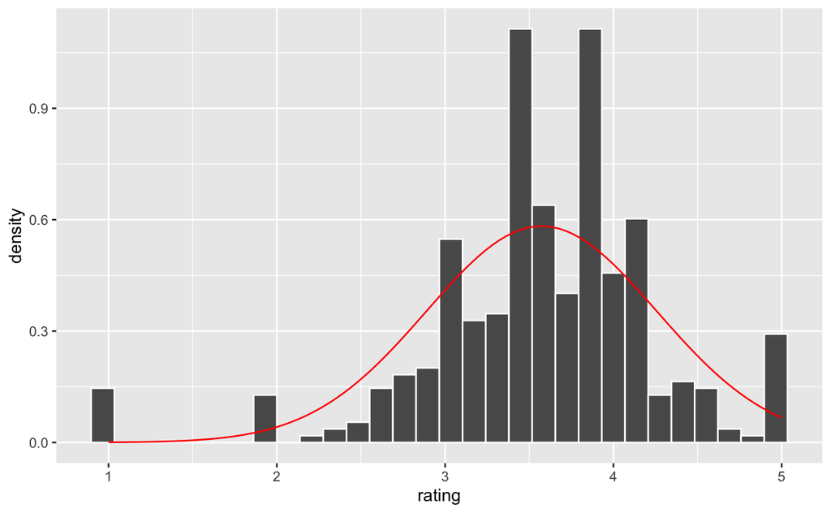

```r
phones %>%
  filter(brand == "Samsung") %>%
  ggplot() +
  geom_histogram(aes(x = rating, y = after_stat(density)), colour = "white") +
  stat_function(
    fun = dnorm,
    args = list(
      mean = samsung_rating_stats$mean,
      sd = samsung_rating_stats$sd
    ),
    colour = "red"
  )
```

### Q4 & Extension

We can be more quantitative in comparing the distribution of top brand ratings with a normal distribution. You calculated the mean() and sd() of your distribution in an earlier question. Use these values to calculate the proportions of ratings within one-, two- and three standard deviations of the mean. Compare these proportions with those you expect for a normal distribution.

Interpretation: - Considering the proportion of ratings that fall within 1SD, 2SD and 3SD when compared to what we would expect from a normal distribution. A higher proportion of ratings are within 1SD than we would expect; however, a smaller number are within both 2SD and 3SD. This suggests that a larger proportion than expected in a normal distribution is very close to the mean; however, the overall distribution is more widely spread.

- Considering the QQPLot and QQline, this would suggest that this data does not fit a normal distribution. If it were a normal distribution we would expect the plot points to more closely resemble a straight line and more closely align with the QQline.
- Considering the Skewness of the data -0.9349111, it is moderately negatively skewed, which would suggest the data does not fit a normal distribution.
- The Z Rating calculations show that there are 8 observations which could be considered outliers.

What we’d expect for a normal distribution:

```r
100 * (pnorm(q = 1) - pnorm(q = -1))
```

```
[1] 68.26895
```

```r
100 * (pnorm(q = 2) - pnorm(q = -2))
```

```
[1] 95.44997
```

```r
100 * (pnorm(q = 3) - pnorm(q = -3))
```

```
[1] 99.73002
```

For Samsung data:

| prop_within_1sd |
| --- |
| 0.7934509 |

| prop_within_2sd |
| --- |
| 0.9193955 |

| prop_within_3sd |
| --- |
| 0.9798489 |

```
                    Expected | Samsung Data
```

Proportion Within 1SD 68.26895 | 79.34509 (0.7934509 * 100) Proportion Within 2SD 95.44997 | 91.93955 (0.9193955 * 100) Proportion Within 3SD 99.73002 | 97.98489 (0.9798489 * 100)

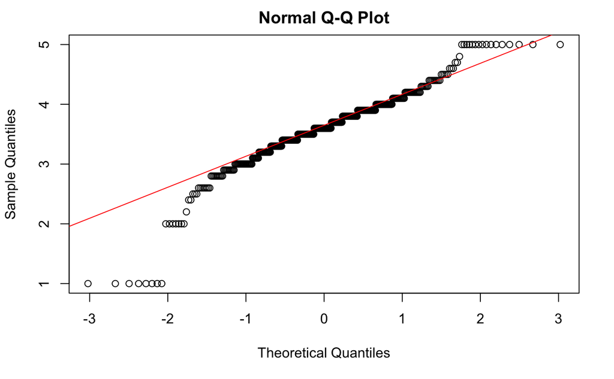

```r
qqnorm(samsung_ratings$rating)
qqline(samsung_ratings$rating, col = "red")
```

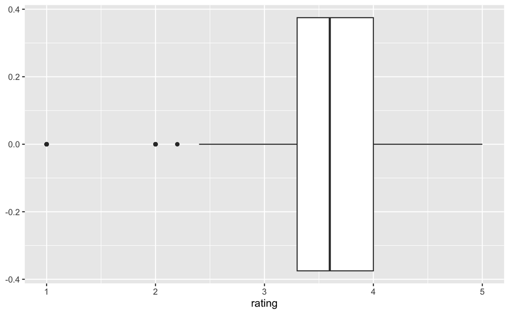

```r
samsung_ratings %>%
  ggplot() +
  geom_boxplot(aes(x = rating))
```

```r
samsung_ratings %>%
  summarise(skewness = skewness(rating, type = 1))
```

| skewness |
| --- |
| -0.9349111 |

```r
NA
```

```r
samsung_ratings_scaled <- samsung_ratings %>%
  mutate(z_rating = scale(rating))

samsung_ratings_scaled %>%
  filter(!between(z_rating, left = -3, right = 3))
```

| asin | brand | title | url | image | rating | review_url | total_reviews | prices | z_rating |
| --- | --- | --- | --- | --- | --- | --- | --- | --- | --- |
| B00R3R6W3W | Samsung | Samsung Convoy 3 Non-Camera, Gray (Verizon Wireless) | https://www.amazon.com/Samsung-Convoy-Non-Camera-Verizon-Wireless/dp/B00R3R6W3W | https://m.media-amazon.com/images/I/81iGOVN07rL._AC_UY218_SEARCH213888_FMwebp_QL75_.jpg | 1 | https://www.amazon.com/product-reviews/B00R3R6W3W | 2 | NA | -3.757816 |
| B01HQTL47A | Samsung | Samsung G920A Galaxy S6 32GB, Black Saphire (Renewed) | https://www.amazon.com/Samsung-G920A-Galaxy-Saphire-Renewed/dp/B01HQTL47A | https://m.media-amazon.com/images/I/31prNuzjoCL._AC_UY218_SEARCH213888_FMwebp_QL75_.jpg | 1 | https://www.amazon.com/product-reviews/B01HQTL47A | 2 | $135.98 | -3.757816 |
| B079TZ8NKG | Samsung | Samsung Galaxy S6 Edge G925T 64GB Gold Platinum - T-Mobile | https://www.amazon.com/Samsung-Galaxy-Edge-G925T-Platinum/dp/B079TZ8NKG | https://m.media-amazon.com/images/I/916OH+JvtDL._AC_UY218_SEARCH213888_FMwebp_QL75_.jpg | 1 | https://www.amazon.com/product-reviews/B079TZ8NKG | 1 | NA | -3.757816 |
| B07HC74RMG | Samsung | Samsung Galaxy S9 Enterprise Edition 64 GB Unlocked Phone With FREE Cellairis Phone Case & Screen Protector | https://www.amazon.com/Samsung-Enterprise-Unlocked-Cellairis-Protector/dp/B07HC74RMG | https://m.media-amazon.com/images/I/715LLCKpQEL._AC_UY218_SEARCH213888_FMwebp_QL75_.jpg | 1 | https://www.amazon.com/product-reviews/B07HC74RMG | 1 | $874.18 | -3.757816 |
| B07NLLFGTL | Samsung | Samsung Galaxy Note9 Smartphone 6.4" AT&T Android 512GB (Certified Refurbished) (Lilac Purple) | https://www.amazon.com/Samsung-Smartphone-Android-Certified-Refurbished/dp/B07NLLFGTL | https://m.media-amazon.com/images/I/51pdXCj33kL._AC_UY218_SEARCH213888_FMwebp_QL75_.jpg | 1 | https://www.amazon.com/product-reviews/B07NLLFGTL | 1 | $664.95 | -3.757816 |
| B07PC21HKM | Samsung | Samsung Galaxy S9+ SM-G9650 Dual Sim 128GB 6GB RAM 6.2" Super AMOLED Factory Unlocked - No Warranty (Sunrise Gold) (Renewed) | https://www.amazon.com/Samsung-Galaxy-SM-G9650-Factory-Unlocked/dp/B07PC21HKM | https://m.media-amazon.com/images/I/51jCNLU12JL._AC_UY218_SEARCH213888_FMwebp_QL75_.jpg | 1 | https://www.amazon.com/product-reviews/B07PC21HKM | 1 | $399.99 | -3.757816 |
| B07QG4FJ8Z | Samsung | Samsung Galaxy J2 Core 2018 Factory Unlocked 4G LTE (USA Latin Caribbean) Android Oreo SM-J260M Dual Sim 8MP 16GB (Gold) | https://www.amazon.com/Samsung-Factory-Unlocked-Caribbean-SM-J260M/dp/B07QG4FJ8Z | https://m.media-amazon.com/images/I/31f-b5A00bL._AC_UY218_SEARCH213888_FMwebp_QL75_.jpg | 1 | https://www.amazon.com/product-reviews/B07QG4FJ8Z | 1 | $103.74 | -3.757816 |
| B07SRD6SVX | Samsung | Samsung Galaxy S10e Verizon + GSM Unlocked 128GB Prism White (Renewed) | https://www.amazon.com/Samsung-Galaxy-Verizon-Unlocked-Renewed/dp/B07SRD6SVX | https://m.media-amazon.com/images/I/71+figFvKvL._AC_UY218_SEARCH213888_FMwebp_QL75_.jpg | 1 | https://www.amazon.com/product-reviews/B07SRD6SVX | 1 | $498.43 | -3.757816 |

```r
NA
```